# Introduction to Computer Vision: Plant Seedlings Classification

## Problem Statement

### Context

In recent times, the field of agriculture has been in urgent need of modernizing, since the amount of manual work people need to put in to check if plants are growing correctly is still highly extensive. Despite several advances in agricultural technology, people working in the agricultural industry still need to have the ability to sort and recognize different plants and weeds, which takes a lot of time and effort in the long term. The potential is ripe for this trillion-dollar industry to be greatly impacted by technological innovations that cut down on the requirement for manual labor, and this is where Artificial Intelligence can actually benefit the workers in this field, as **the time and energy required to identify plant seedlings will be greatly shortened by the use of AI and Deep Learning.** The ability to do so far more efficiently and even more effectively than experienced manual labor, could lead to better crop yields, the freeing up of human inolvement for higher-order agricultural decision making, and in the long term will result in more sustainable environmental practices in agriculture as well.

### Objective

The aim of this project is to Build a Convolutional Neural Netowrk to classify plant seedlings into their respective categories.

### Data Dictionary

The Aarhus University Signal Processing group, in collaboration with the University of Southern Denmark, has recently released a dataset containing **images of unique plants belonging to 12 different species.**

- The dataset can be download from Olympus.
- The data file names are:
  - images.npy
  - Labels.csv
- Due to the large volume of data, the images were converted to the images.npy file and the labels are also put into Labels.csv, so that you can work on the data/project seamlessly without having to worry about the high data volume.
- The goal of the project is to create a classifier capable of determining a plant's species from an image.

**List of Species**

- Black-grass
- Charlock
- Cleavers
- Common Chickweed
- Common Wheat
- Fat Hen
- Loose Silky-bent
- Maize
- Scentless Mayweed
- Shepherds Purse
- Small-flowered Cranesbill
- Sugar beet

### **Note: Please use GPU runtime on Google Colab to execute the code faster.**

## Importing necessary libraries

```python
# Installing opencv-python package to import cv2
#!pip install opencv-python
```

```python
import os
import numpy as np                                                                               # Importing numpy for Matrix Operations
import pandas as pd                                                                              # Importing pandas to read CSV files
import matplotlib.pyplot as plt                                                                  # Importting matplotlib for Plotting and visualizing images
import math                                                                                      # Importing math module to perform mathematical operations
import cv2                                                                                       # Importing cv2 for image processing
import seaborn as sns                                                                            # Importing seaborn to plot graphs

# Tensorflow modules
import tensorflow as tf
from tensorflow.keras.preprocessing.image import ImageDataGenerator                              # Importing the ImageDataGenerator for data augmentation
from tensorflow.keras.models import Sequential                                                   # Importing the sequential module to define a sequential model
from tensorflow.keras.layers import Dense,Dropout,Flatten,Conv2D,MaxPooling2D,BatchNormalization # Defining all the layers to build our CNN Model
from tensorflow.keras.layers import Input,Rescaling,Resizing                                     # Defining all the layers to build our CNN Model
from tensorflow.keras.optimizers import Adam,SGD                                                 # Importing the optimizers which can be used in our model
from sklearn import preprocessing                                                                # Importing the preprocessing module to preprocess the data
from sklearn.model_selection import train_test_split                                             # Importing train_test_split function to split the data into train and test
from sklearn.metrics import confusion_matrix                                                     # Importing confusion_matrix to plot the confusion matrix
from sklearn.preprocessing import LabelBinarizer
from keras.applications import VGG16,ResNet50,InceptionV3,DenseNet121,EfficientNetB0

from tensorflow.keras import backend
from keras.callbacks import ReduceLROnPlateau
from sklearn import metrics
import random

# Ignore warnings
import warnings
warnings.filterwarnings('ignore')
```

## Loading the dataset

```python
# Loading the images & labels files
images = np.load('images.npy')
labels = pd.read_csv('Labels.csv')
```

## Data Overview

### Understand the shape of the dataset

```python
#Printing the shape of the data.
print(images.shape)
print(labels.shape)
```

```
(4750, 128, 128, 3)
(4750, 1)
```

#### Observations

- The input digitized images file seems to contain **4750** color images (**3** channels) with **128x128** pixels.
- The target label for each of those images are in labels file which also contains **4750** labels in it over **1** channel.

#### Identifying Distinct Labels

```python
pd.DataFrame(labels['Label'].unique())
```

|  | 0 |
| --- | --- |
| 0 | Small-flowered Cranesbill |
| 1 | Fat Hen |
| 2 | Shepherds Purse |
| 3 | Common wheat |
| 4 | Common Chickweed |
| 5 | Charlock |
| 6 | Cleavers |
| 7 | Scentless Mayweed |
| 8 | Sugar beet |
| 9 | Maize |
| 10 | Black-grass |
| 11 | Loose Silky-bent |

#### Observations

- There are 12 distinct labels in our dataset, which means the images file contains images of 12 different varieties of plants.

## Exploratory Data Analysis

- EDA is an important part of any project involving data.
- It is important to investigate and understand the data better before building a model with it.
- A few questions have been mentioned below which will help you understand the data better.
- A thorough analysis of the data, in addition to the questions mentioned below, should be done.
1. How are these different category plant images different from each other?
2. Is the dataset provided an imbalance? (Check with using bar plots)

[figure not shown]

```python
# Extracting list of distinct labels.
label_ids=labels['Label'].values

# Display one random image for each label in a 3x4 grid
rows = 3
cols = 4
fig, axes = plt.subplots(rows, cols, figsize=(10,8))

# Track which labels have been displayed
displayed_labels = set()

for ax in axes.flatten():
    # Select a random label that hasn't been displayed yet
    while True:
        random_index = np.random.randint(len(label_ids))
        label = label_ids[random_index]
        if label not in displayed_labels:
            displayed_labels.add(label)
            break

    # Find all images with the selected label
    images_with_label = [idx for idx, lbl in enumerate(label_ids) if lbl == label]

    # Pick a random image with the selected label
    random_image_index = np.random.choice(images_with_label)
    image = images[random_image_index]

    # Display the image
    ax.imshow(image)
    ax.set_title(f'Label: {label}')
    ax.axis('off')

# Adjust layout and display the plot
plt.tight_layout()
plt.show()
```

#### Observations

- We can visually look at the plant images to distinguish the plants from each other based on their features.
- Just like a Neural Network would do when presented with these digitized images to learn from i.e. identifying patterns associated with labels.
- We can see that even though it is easier to tell apart most of the different plants.
- However, there definitely seems to be some varieties of plants which look very similar.
- This is why it takes eye of an expert who has seen these plants for years, to identify which plant is which exactly.
- Amazing thing is the same level of knowledge can be acquired by the CNN model in a matter of minutes.

### Checking the distribution of Target variables

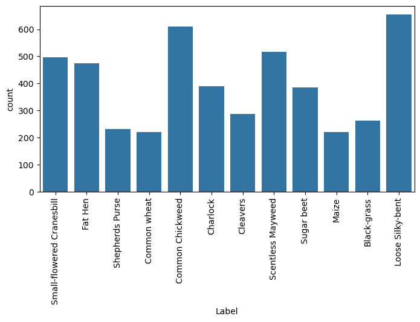

```python
plt.figure(figsize=(8,4))
sns.countplot(x=labels['Label'])
plt.xticks(rotation='vertical');
```

#### Observations

- The data looks pretty **balanced** and even though there are some labels having higher count than others, no label is monopolizing the distribution.
- That being said, the mostly found variety of the plant is the Loose ***Silky-bent***, followed by* **Common Chickweek***.
- One of the least found plants include ***Common wheat*** & ***Shepherds Purse***.
- In this scenario, **accuracy** would be a good measure of **model performance & tuning**.

## Data Pre-Processing

### Convert the BGR images to RGB images.

```python
# Converting the images from BGR to RGB using cvtColor function of OpenCV
for i in range(len(images)):
  images[i] = cv2.cvtColor(images[i], cv2.COLOR_BGR2RGB)
```

### Resize the images

As the size of the images is large, it may be computationally expensive to train on these larger images; therefore, it is preferable to reduce the image size from 128 to 64.

```python
resized_images=[]
height = 64
width =  64
dimensions = (width, height)
for i in range(len(images)):
  resized_images.append( cv2.resize(images[i], dimensions, interpolation=cv2.INTER_LINEAR))
```

#### Image before resizing

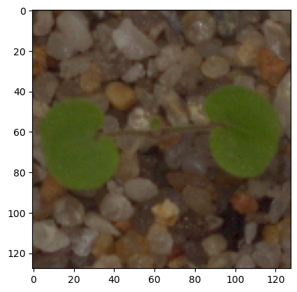

```python
plt.imshow(images[0])
```

#### Image after resizing

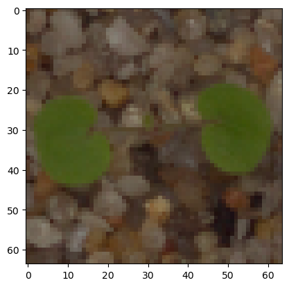

```python
plt.imshow(resized_images[0])
```

### Data Preparation for Modeling

- Before you proceed to build a model, you need to **split the data into train, test, and validation** to be able to evaluate the model that you build on the train data
- You'll have to **encode categorical** features and scale the pixel values.
- You will **build a model** using the train data and then check its performance

#### Split the dataset

- Since we only have under 5k images in total & since we more images to train a CNN, we can keep the split of 80:10:10
  - With 80% of data used for training.
  - 10% of data used to evaluate the performance while tuning the model.
  - 10% of data used to test the performance of the final model on unseen data.

```python
# Splitting the input data into 90% temp data & 10% test data
X_temp, X_test, y_temp, y_test = train_test_split(
	np.array(resized_images), labels , test_size=0.1, random_state=42, stratify=labels
)

# Splitting the temp data into 90% train data & 10% validation data
X_train, X_val, y_train, y_val = train_test_split(
	X_temp, y_temp, test_size=0.1, random_state=42,stratify=y_temp
)
```

- Let's look at the shape of the split data

```python
print(X_train.shape, y_train.shape)
print(X_val.shape, y_val.shape)
print(X_test.shape, y_test.shape)
```

```
(3847, 64, 64, 3) (3847, 1)
(428, 64, 64, 3) (428, 1)
(475, 64, 64, 3) (475, 1)
```

#### Observations

- We can see that we now have **3847** images for training the model.
  - Which now has **64x64** pixels instead of **128x128**, still with **3** channel color images.
- **428** images for evaluating the performance of the **evolving models**.
- **475** images for testing the **final model** predictions on unseen data.

#### Encode the target labels

```python
# Let's encode the target variables for train, validation & test datasets
enc = LabelBinarizer()
y_train_encoded = enc.fit_transform(y_train)
y_val_encoded=enc.transform(y_val)
y_test_encoded=enc.transform(y_test)
```

- Let's look at the shape of the split data

```python
print(y_train_encoded.shape)
print(y_val_encoded.shape)
print(y_test_encoded.shape)
```

```
(3847, 12)
(428, 12)
(475, 12)
```

#### Data Normalization

```python
# Normalizing the image pixels to get values between 0 & 1
X_train_normalized = X_train.astype('float32')/255.0
X_val_normalized = X_val.astype('float32')/255.0
X_test_normalized = X_test.astype('float32')/255.0
```

- **Data Normalization** is done to reduce the complexity of processing high numeric values.
- It is also done to avoid the problem of **exploding or vanishing gradients**.

## Model Building

```python
# Clearing backend
backend.clear_session()
```

```
WARNING:tensorflow:From C:\Users\shiji\AppData\Roaming\Python\Python312\site-packages\keras\src\backend\common\global_state.py:82: The name tf.reset_default_graph is deprecated. Please use tf.compat.v1.reset_default_graph instead.
```

```python
# Fixing the seed for random number generators to be able to reproduce the same results every time we run the code
np.random.seed(42)
random.seed(42)
tf.random.set_seed(42)
```

```python
# Intializing a Sequential model1
model1 = Sequential()

# Adding first conv layer with 128 filters and kernel size 3x3 , padding 'same' provides the output size same as the input size
# Input_shape denotes input image dimension of MNIST images
model1.add(Conv2D(128, (3, 3), activation='relu', padding="same", input_shape=(64, 64, 3)))

# Adding max pooling to reduce the size of output of first conv layer
model1.add(MaxPooling2D((2, 2), padding = 'same'))

# Adding remaining Convolution filters & Max Pooling filters to extract more features
model1.add(Conv2D(64, (3, 3), activation='relu', padding="same"))
model1.add(MaxPooling2D((2, 2), padding = 'same'))
model1.add(Conv2D(32, (3, 3), activation='relu', padding="same"))
model1.add(MaxPooling2D((2, 2), padding = 'same'))

# flattening the output of the conv layer after max pooling to make it ready for creating dense connections
model1.add(Flatten())

# Adding a fully connected dense layer with 16 neurons
model1.add(Dense(16, activation='relu'))
model1.add(Dropout(0.3))

# Adding the output layer with 12 neurons and activation functions as softmax since this is a multi-class classification problem
model1.add(Dense(12, activation='softmax'))

# Using Adam Optimizer
opt = Adam()

# Compile model1
model1.compile(optimizer=opt, loss='categorical_crossentropy', metrics=['accuracy'])

# Generating the summary of the model1
model1.summary()
```

```
Model: "sequential"
```

```
┏━━━━━━━━━━━━━━━━━━━━━━━━━━━━━━━━━━━━━━┳━━━━━━━━━━━━━━━━━━━━━━━━━━━━━┳━━━━━━━━━━━━━━━━━┓
┃ Layer (type)                         ┃ Output Shape                ┃         Param # ┃
┡━━━━━━━━━━━━━━━━━━━━━━━━━━━━━━━━━━━━━━╇━━━━━━━━━━━━━━━━━━━━━━━━━━━━━╇━━━━━━━━━━━━━━━━━┩
│ conv2d (Conv2D)                      │ (None, 64, 64, 128)         │           3,584 │
├──────────────────────────────────────┼─────────────────────────────┼─────────────────┤
│ max_pooling2d (MaxPooling2D)         │ (None, 32, 32, 128)         │               0 │
├──────────────────────────────────────┼─────────────────────────────┼─────────────────┤
│ conv2d_1 (Conv2D)                    │ (None, 32, 32, 64)          │          73,792 │
├──────────────────────────────────────┼─────────────────────────────┼─────────────────┤
│ max_pooling2d_1 (MaxPooling2D)       │ (None, 16, 16, 64)          │               0 │
├──────────────────────────────────────┼─────────────────────────────┼─────────────────┤
│ conv2d_2 (Conv2D)                    │ (None, 16, 16, 32)          │          18,464 │
├──────────────────────────────────────┼─────────────────────────────┼─────────────────┤
│ max_pooling2d_2 (MaxPooling2D)       │ (None, 8, 8, 32)            │               0 │
├──────────────────────────────────────┼─────────────────────────────┼─────────────────┤
│ flatten (Flatten)                    │ (None, 2048)                │               0 │
├──────────────────────────────────────┼─────────────────────────────┼─────────────────┤
│ dense (Dense)                        │ (None, 16)                  │          32,784 │
├──────────────────────────────────────┼─────────────────────────────┼─────────────────┤
│ dropout (Dropout)                    │ (None, 16)                  │               0 │
├──────────────────────────────────────┼─────────────────────────────┼─────────────────┤
│ dense_1 (Dense)                      │ (None, 12)                  │             204 │
└──────────────────────────────────────┴─────────────────────────────┴─────────────────┘
```

```
 Total params: 128,828 (503.23 KB)
```

```
 Trainable params: 128,828 (503.23 KB)
```

```
 Non-trainable params: 0 (0.00 B)
```

#### Observations

- This is the **first model** we are building using the available images, **before** we utilize **data augmentations** or any **pre-trained models** to improve performance.
- We can see that even after adding multiple **convolutional** & **pooling** layers as well, with filters ranging from **128** to **32**, the number of trainable parameters is only around **128k**.
- In the **Dense** layer followed by the **Flatten** layer, a dropout of **0.3** is added, which will result in **30% dropout rate**.
  - This will help **prevent overfitting** by randomly dropping 30% of the units in the dense layer during training.
- **Optimizer** being used for this model is **Adam**.
- Since this is a **multi-class classification** problem, we used the **categorical_crossentropy** loss function.
- Metric of choice is **accuracy**, as the data distribution of the target variable is pretty **balanced**.
- **All layers** prior to the output layer uses **relu** as the activation function to introduce non-linearity into the model learning.
- However, **output layer** utilizes **softmax** as the activation function as we are trying to solve a multi-class classification problem.

#### Fitting the model on Train data

```python
history1 = model1.fit(
            X_train_normalized, y_train_encoded,
            epochs=30,
            validation_data=(X_val_normalized,y_val_encoded),
            batch_size=32,
            verbose=1
)
```

```
121/121 ━━━━━━━━━━━━━━━━━━━━ 9s 63ms/step - accuracy: 0.1225 - loss: 2.4671 - val_accuracy: 0.1846 - val_loss: 2.3130
121/121 ━━━━━━━━━━━━━━━━━━━━ 7s 61ms/step - accuracy: 0.2390 - loss: 2.2268 - val_accuracy: 0.3925 - val_loss: 1.8797
121/121 ━━━━━━━━━━━━━━━━━━━━ 7s 61ms/step - accuracy: 0.3109 - loss: 1.9586 - val_accuracy: 0.4112 - val_loss: 1.6954
121/121 ━━━━━━━━━━━━━━━━━━━━ 7s 61ms/step - accuracy: 0.3198 - loss: 1.9061 - val_accuracy: 0.4089 - val_loss: 1.6282
121/121 ━━━━━━━━━━━━━━━━━━━━ 7s 61ms/step - accuracy: 0.3609 - loss: 1.7851 - val_accuracy: 0.4299 - val_loss: 1.6025
121/121 ━━━━━━━━━━━━━━━━━━━━ 7s 61ms/step - accuracy: 0.3547 - loss: 1.7344 - val_accuracy: 0.4556 - val_loss: 1.5083
121/121 ━━━━━━━━━━━━━━━━━━━━ 7s 61ms/step - accuracy: 0.3534 - loss: 1.6792 - val_accuracy: 0.4930 - val_loss: 1.4231
121/121 ━━━━━━━━━━━━━━━━━━━━ 7s 61ms/step - accuracy: 0.4032 - loss: 1.6021 - val_accuracy: 0.5164 - val_loss: 1.3986
121/121 ━━━━━━━━━━━━━━━━━━━━ 7s 62ms/step - accuracy: 0.4051 - loss: 1.5693 - val_accuracy: 0.5280 - val_loss: 1.3450
121/121 ━━━━━━━━━━━━━━━━━━━━ 7s 61ms/step - accuracy: 0.4374 - loss: 1.5271 - val_accuracy: 0.5631 - val_loss: 1.2811
121/121 ━━━━━━━━━━━━━━━━━━━━ 7s 61ms/step - accuracy: 0.4478 - loss: 1.4712 - val_accuracy: 0.5561 - val_loss: 1.2312
121/121 ━━━━━━━━━━━━━━━━━━━━ 7s 61ms/step - accuracy: 0.4672 - loss: 1.3741 - val_accuracy: 0.5911 - val_loss: 1.1869
121/121 ━━━━━━━━━━━━━━━━━━━━ 7s 61ms/step - accuracy: 0.4659 - loss: 1.4096 - val_accuracy: 0.5794 - val_loss: 1.2228
121/121 ━━━━━━━━━━━━━━━━━━━━ 7s 61ms/step - accuracy: 0.4764 - loss: 1.3790 - val_accuracy: 0.5514 - val_loss: 1.2605
121/121 ━━━━━━━━━━━━━━━━━━━━ 7s 62ms/step - accuracy: 0.4537 - loss: 1.3874 - val_accuracy: 0.5187 - val_loss: 1.2854
121/121 ━━━━━━━━━━━━━━━━━━━━ 7s 62ms/step - accuracy: 0.4743 - loss: 1.3386 - val_accuracy: 0.5794 - val_loss: 1.2009
121/121 ━━━━━━━━━━━━━━━━━━━━ 8s 63ms/step - accuracy: 0.5128 - loss: 1.2947 - val_accuracy: 0.5607 - val_loss: 1.2005
121/121 ━━━━━━━━━━━━━━━━━━━━ 7s 61ms/step - accuracy: 0.5206 - loss: 1.2237 - val_accuracy: 0.5444 - val_loss: 1.3098
121/121 ━━━━━━━━━━━━━━━━━━━━ 7s 61ms/step - accuracy: 0.5108 - loss: 1.2642 - val_accuracy: 0.5771 - val_loss: 1.1475
121/121 ━━━━━━━━━━━━━━━━━━━━ 7s 61ms/step - accuracy: 0.5299 - loss: 1.2259 - val_accuracy: 0.6168 - val_loss: 1.0645
121/121 ━━━━━━━━━━━━━━━━━━━━ 7s 61ms/step - accuracy: 0.5423 - loss: 1.1759 - val_accuracy: 0.5841 - val_loss: 1.1793
121/121 ━━━━━━━━━━━━━━━━━━━━ 7s 61ms/step - accuracy: 0.5366 - loss: 1.2180 - val_accuracy: 0.6192 - val_loss: 1.0805
121/121 ━━━━━━━━━━━━━━━━━━━━ 7s 61ms/step - accuracy: 0.5309 - loss: 1.2206 - val_accuracy: 0.6238 - val_loss: 1.0518
121/121 ━━━━━━━━━━━━━━━━━━━━ 7s 61ms/step - accuracy: 0.5411 - loss: 1.1626 - val_accuracy: 0.6565 - val_loss: 1.0519
121/121 ━━━━━━━━━━━━━━━━━━━━ 7s 61ms/step - accuracy: 0.5445 - loss: 1.1500 - val_accuracy: 0.6332 - val_loss: 1.0668
121/121 ━━━━━━━━━━━━━━━━━━━━ 7s 61ms/step - accuracy: 0.5499 - loss: 1.1423 - val_accuracy: 0.6425 - val_loss: 1.0499
121/121 ━━━━━━━━━━━━━━━━━━━━ 7s 61ms/step - accuracy: 0.5843 - loss: 1.0657 - val_accuracy: 0.6893 - val_loss: 0.9637
121/121 ━━━━━━━━━━━━━━━━━━━━ 8s 62ms/step - accuracy: 0.5724 - loss: 1.0823 - val_accuracy: 0.6799 - val_loss: 0.9620
121/121 ━━━━━━━━━━━━━━━━━━━━ 8s 62ms/step - accuracy: 0.5871 - loss: 1.0419 - val_accuracy: 0.6799 - val_loss: 0.9903
121/121 ━━━━━━━━━━━━━━━━━━━━ 8s 62ms/step - accuracy: 0.5968 - loss: 1.0350 - val_accuracy: 0.6776 - val_loss: 0.9922
```

#### Evaluating the Model Performance on Train & Validation data

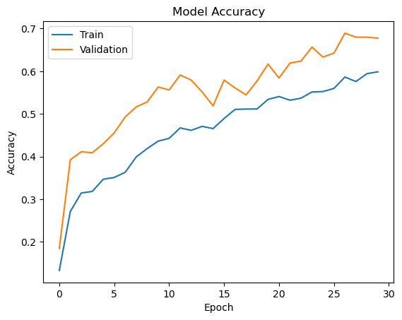

```python
plt.plot(history1.history['accuracy'])
plt.plot(history1.history['val_accuracy'])
plt.title('Model Accuracy')
plt.ylabel('Accuracy')
plt.xlabel('Epoch')
plt.legend(['Train', 'Validation'], loc='upper left')
plt.show()
```

#### Observations

- We can see that both **model accuracy** on both **Train & Validation data** shows an **upward trend** throughout all the epochs, going up to mid-60s.
- Validation accuracy is consistently better than Train accuracy, which shows that there is no overfitting.

#### Evaluating the Model Performance on Test data

```python
accuracy = model1.evaluate(X_test_normalized, y_test_encoded, verbose=2)
```

```
15/15 - 0s - 19ms/step - accuracy: 0.6737 - loss: 0.9968
```

#### Observations

- Even on the **test data**, we could only achieve an **accuracy** of ***67.37***.

#### Plotting the Confusion Matrix

```python
# Here we would get the output as probablities for each category
y_pred=model1.predict(X_test_normalized)
```

```
15/15 ━━━━━━━━━━━━━━━━━━━━ 0s 23ms/step
```

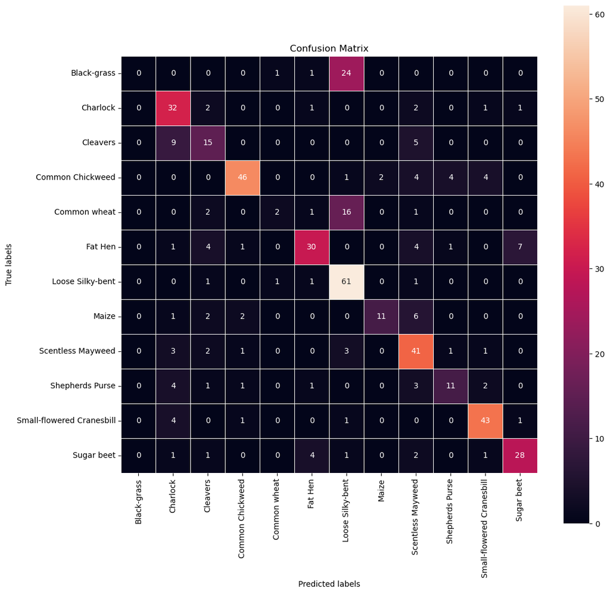

```python
# Obtaining the categorical values from y_test_encoded and y_pred
y_pred_arg=np.argmax(y_pred,axis=1)
y_test_arg=np.argmax(y_test_encoded,axis=1)

# Plotting the Confusion Matrix using confusion matrix() function which is also predefined tensorflow module
confusion_matrix = tf.math.confusion_matrix(y_test_arg,y_pred_arg)
f, ax = plt.subplots(figsize=(12, 12))
sns.heatmap(
    confusion_matrix,
    annot=True,
    linewidths=.4,
    fmt="d",
    square=True,
    ax=ax
)
# Setting the labels to both the axes
ax.set_xlabel('Predicted labels');ax.set_ylabel('True labels');
ax.set_title('Confusion Matrix');
ax.xaxis.set_ticklabels(list(enc.classes_),rotation=90)
ax.yaxis.set_ticklabels(list(enc.classes_),rotation=0)
plt.show()
```

#### Observations

- We can see that numerous times (***24***)* **Black-grass*** was **incorrectly predicted** as ***Loose Silky-bent***.
- Even ***Common wheat*** was often times (***16***)* *incorrectly predicted** as ***Loose Silky-bent***.
- While ***Loose Silky-bent*** itself was almost always **correctly predicted**.
- Overall, we can see that the **performance isn't great** for this model and it definitely **requires tuning**.

#### Plotting Classification Report

```python
# Plotting the classification report
cr=metrics.classification_report(y_test_arg,y_pred_arg)
print(cr)
```

```
              precision    recall  f1-score   support

           0       0.00      0.00      0.00        26
           1       0.58      0.82      0.68        39
           2       0.50      0.52      0.51        29
           3       0.88      0.75      0.81        61
           4       0.50      0.09      0.15        22
           5       0.77      0.62      0.69        48
           6       0.57      0.94      0.71        65
           7       0.85      0.50      0.63        22
           8       0.59      0.79      0.68        52
           9       0.65      0.48      0.55        23
          10       0.83      0.86      0.84        50
          11       0.76      0.74      0.75        38

    accuracy                           0.67       475
   macro avg       0.62      0.59      0.58       475
weighted avg       0.65      0.67      0.64       475
```

#### Observations

- As stated before as well, the performance of the model does seem to improve over each epoch, but it still doesn't reach a good number because the **learning data isn't rich enough**.
- Let's enrich the input data by doing some **data augmentations**.

## Model Performance Improvement

**Reducing the Learning Rate:**

**Hint**: Use **ReduceLRonPlateau()** function that will be used to decrease the learning rate by some factor, if the loss is not decreasing for some time. This may start decreasing the loss at a smaller learning rate. There is a possibility that the loss may still not decrease. This may lead to executing the learning rate reduction again in an attempt to achieve a lower loss.

```python
# Code to monitor val_accuracy
learning_rate_reduction = ReduceLROnPlateau(monitor='val_accuracy',
                                            patience=3,
                                            verbose=1,
                                            factor=0.5,
                                            min_lr=0.00001)
```

### **Data Augmentation**

Remember, **data augmentation should not be used in the validation/test data set**.

```python
# Clearing backend again before building the next model
from tensorflow.keras import backend
backend.clear_session()

# Fixing the seed for random number generators
import random
np.random.seed(42)
random.seed(42)
tf.random.set_seed(42)
```

```python
# Let's start by rotating the images by a range of 0 - 20 degrees within which the images are randomly rotated
train_datagen = ImageDataGenerator(
    rotation_range=20,
    fill_mode='nearest'
)
```

#### Observations

- The only **augmentations** we applied on our input data set is to **rotate** the image up to 20 degrees & **fill_mode='nearest'**.
- Other augmentations would actually create more noise than information as there is already a significant amount of similarities between different varieties of plants.
  - Augmentations like **horizontal_flip**, **vertical_flip** wouldn't help because there is no upside for plants & flipping the image wouldn't really get any new features to learn.
  - **shear_range** & **zoom** also wouldn't help because of high similarities.
- We also introduced a code block to perform **learning_rate_reduction** every time the **model goes mutliple epochs without improving validation accuracy**.

### Building **Model 2**, which will be fit on Augmented data

#### Changes introduced to the Model architecture

- Added an **extra pair of Convolutional layer with 64 3x3 filters & MaxPooling layer**.
- Added **BatchNormalization** layers after each Convolutional layers to get better at generalizing.
  - This will help with **accelerated training** and **improving the gradient flow**.
- Apart from these 2 changes, we kept the model architecture relatively similar to the original architecture.

```python
# Intializing a Sequential model2
model2 = Sequential()

# Adding first conv layer with 128 filters and kernel size 3x3 , padding 'same' provides the output size same as the input size
# Input_shape denotes input image dimension of MNIST images
model2.add(Conv2D(128, (3, 3), activation='relu', padding="same", input_shape=(64, 64, 3)))

# Adding max pooling to reduce the size of output of first conv layer
model2.add(MaxPooling2D((2, 2), padding = 'same'))

# Adding remaining Convolution filters & Max Pooling filters to extract more features
model2.add(Conv2D(64, (3, 3), activation='relu', padding="same"))
model2.add(MaxPooling2D((2, 2), padding = 'same'))
model2.add(BatchNormalization())
model2.add(Conv2D(64, (3, 3), activation='relu', padding="same"))
model2.add(MaxPooling2D((2, 2), padding = 'same'))
model2.add(BatchNormalization())
model2.add(Conv2D(32, (3, 3), activation='relu', padding="same"))
model2.add(MaxPooling2D((2, 2), padding = 'same'))
model2.add(BatchNormalization())

# flattening the output of the conv layer after max pooling to make it ready for creating dense connections
model2.add(Flatten())

# Adding a fully connected dense layer with 16 neurons
model2.add(Dense(16, activation='relu'))
model2.add(Dropout(0.3))

# Adding the output layer with 12 neurons and activation functions as softmax since this is a multi-class classification problem
model2.add(Dense(12, activation='softmax'))

# Using Adam Optimizer
opt = Adam()

# Compile model2
model2.compile(optimizer=opt, loss='categorical_crossentropy', metrics=['accuracy'])

# Generating the summary of the model2
model2.summary()
```

```
Model: "sequential"
```

```
┏━━━━━━━━━━━━━━━━━━━━━━━━━━━━━━━━━━━━━━┳━━━━━━━━━━━━━━━━━━━━━━━━━━━━━┳━━━━━━━━━━━━━━━━━┓
┃ Layer (type)                         ┃ Output Shape                ┃         Param # ┃
┡━━━━━━━━━━━━━━━━━━━━━━━━━━━━━━━━━━━━━━╇━━━━━━━━━━━━━━━━━━━━━━━━━━━━━╇━━━━━━━━━━━━━━━━━┩
│ conv2d (Conv2D)                      │ (None, 64, 64, 128)         │           3,584 │
├──────────────────────────────────────┼─────────────────────────────┼─────────────────┤
│ max_pooling2d (MaxPooling2D)         │ (None, 32, 32, 128)         │               0 │
├──────────────────────────────────────┼─────────────────────────────┼─────────────────┤
│ conv2d_1 (Conv2D)                    │ (None, 32, 32, 64)          │          73,792 │
├──────────────────────────────────────┼─────────────────────────────┼─────────────────┤
│ max_pooling2d_1 (MaxPooling2D)       │ (None, 16, 16, 64)          │               0 │
├──────────────────────────────────────┼─────────────────────────────┼─────────────────┤
│ batch_normalization                  │ (None, 16, 16, 64)          │             256 │
│ (BatchNormalization)                 │                             │                 │
├──────────────────────────────────────┼─────────────────────────────┼─────────────────┤
│ conv2d_2 (Conv2D)                    │ (None, 16, 16, 64)          │          36,928 │
├──────────────────────────────────────┼─────────────────────────────┼─────────────────┤
│ max_pooling2d_2 (MaxPooling2D)       │ (None, 8, 8, 64)            │               0 │
├──────────────────────────────────────┼─────────────────────────────┼─────────────────┤
│ batch_normalization_1                │ (None, 8, 8, 64)            │             256 │
│ (BatchNormalization)                 │                             │                 │
├──────────────────────────────────────┼─────────────────────────────┼─────────────────┤
│ conv2d_3 (Conv2D)                    │ (None, 8, 8, 32)            │          18,464 │
├──────────────────────────────────────┼─────────────────────────────┼─────────────────┤
│ max_pooling2d_3 (MaxPooling2D)       │ (None, 4, 4, 32)            │               0 │
├──────────────────────────────────────┼─────────────────────────────┼─────────────────┤
│ batch_normalization_2                │ (None, 4, 4, 32)            │             128 │
│ (BatchNormalization)                 │                             │                 │
├──────────────────────────────────────┼─────────────────────────────┼─────────────────┤
│ flatten (Flatten)                    │ (None, 512)                 │               0 │
├──────────────────────────────────────┼─────────────────────────────┼─────────────────┤
│ dense (Dense)                        │ (None, 16)                  │           8,208 │
├──────────────────────────────────────┼─────────────────────────────┼─────────────────┤
│ dropout (Dropout)                    │ (None, 16)                  │               0 │
├──────────────────────────────────────┼─────────────────────────────┼─────────────────┤
│ dense_1 (Dense)                      │ (None, 12)                  │             204 │
└──────────────────────────────────────┴─────────────────────────────┴─────────────────┘
```

```
 Total params: 141,820 (553.98 KB)
```

```
 Trainable params: 141,500 (552.73 KB)
```

```
 Non-trainable params: 320 (1.25 KB)
```

#### Observations

- After adding the extra layers, the total number of **trainable parameters** went from ***128,828*** to ***141,500***.

#### Fitting the new model on Train data

```python
history2 = model2.fit(
            train_datagen.flow(X_train_normalized, y_train_encoded,
			batch_size=32,
			shuffle=False),
            epochs=30,
            validation_data=(X_val_normalized,y_val_encoded),
            steps_per_epoch=X_train_normalized.shape[0] // 32,
            verbose=1,
			callbacks=[learning_rate_reduction]
)
```

```
120/120 ━━━━━━━━━━━━━━━━━━━━ 11s 71ms/step - accuracy: 0.1704 - loss: 2.4570 - val_accuracy: 0.0911 - val_loss: 2.5091 - learning_rate: 0.0010
120/120 ━━━━━━━━━━━━━━━━━━━━ 0s 2ms/step - accuracy: 0.3125 - loss: 2.0147 - val_accuracy: 0.0935 - val_loss: 2.5102 - learning_rate: 0.0010
120/120 ━━━━━━━━━━━━━━━━━━━━ 8s 68ms/step - accuracy: 0.3624 - loss: 1.8589 - val_accuracy: 0.2570 - val_loss: 2.4078 - learning_rate: 0.0010
120/120 ━━━━━━━━━━━━━━━━━━━━ 0s 2ms/step - accuracy: 0.4688 - loss: 1.6305 - val_accuracy: 0.2336 - val_loss: 2.4004 - learning_rate: 0.0010
120/120 ━━━━━━━━━━━━━━━━━━━━ 8s 68ms/step - accuracy: 0.4692 - loss: 1.5360 - val_accuracy: 0.2687 - val_loss: 2.5247 - learning_rate: 0.0010
120/120 ━━━━━━━━━━━━━━━━━━━━ 0s 2ms/step - accuracy: 0.5312 - loss: 1.3794 - val_accuracy: 0.2687 - val_loss: 2.5379 - learning_rate: 0.0010
120/120 ━━━━━━━━━━━━━━━━━━━━ 8s 69ms/step - accuracy: 0.5372 - loss: 1.3192 - val_accuracy: 0.3178 - val_loss: 2.0282 - learning_rate: 0.0010
120/120 ━━━━━━━━━━━━━━━━━━━━ 0s 2ms/step - accuracy: 0.6562 - loss: 1.3499 - val_accuracy: 0.3178 - val_loss: 2.0076 - learning_rate: 0.0010
120/120 ━━━━━━━━━━━━━━━━━━━━ 8s 69ms/step - accuracy: 0.5854 - loss: 1.1899 - val_accuracy: 0.5467 - val_loss: 1.4275 - learning_rate: 0.0010
120/120 ━━━━━━━━━━━━━━━━━━━━ 0s 2ms/step - accuracy: 0.5312 - loss: 1.2626 - val_accuracy: 0.5000 - val_loss: 1.4923 - learning_rate: 0.0010
120/120 ━━━━━━━━━━━━━━━━━━━━ 8s 69ms/step - accuracy: 0.6159 - loss: 1.0988 - val_accuracy: 0.3294 - val_loss: 2.1587 - learning_rate: 0.0010
  1/120 ━━━━━━━━━━━━━━━━━━━━ 7s 66ms/step - accuracy: 0.6875 - loss: 0.8027
Epoch 12: ReduceLROnPlateau reducing learning rate to 0.0005000000237487257.
120/120 ━━━━━━━━━━━━━━━━━━━━ 0s 2ms/step - accuracy: 0.6875 - loss: 0.8027 - val_accuracy: 0.3435 - val_loss: 2.1051 - learning_rate: 0.0010
120/120 ━━━━━━━━━━━━━━━━━━━━ 9s 70ms/step - accuracy: 0.6553 - loss: 0.9869 - val_accuracy: 0.6636 - val_loss: 1.0254 - learning_rate: 5.0000e-04
120/120 ━━━━━━━━━━━━━━━━━━━━ 0s 2ms/step - accuracy: 0.6562 - loss: 1.1922 - val_accuracy: 0.6612 - val_loss: 1.0116 - learning_rate: 5.0000e-04
120/120 ━━━━━━━━━━━━━━━━━━━━ 9s 69ms/step - accuracy: 0.6789 - loss: 0.9075 - val_accuracy: 0.5374 - val_loss: 1.5140 - learning_rate: 5.0000e-04
  1/120 ━━━━━━━━━━━━━━━━━━━━ 7s 64ms/step - accuracy: 0.8125 - loss: 0.8884
Epoch 16: ReduceLROnPlateau reducing learning rate to 0.0002500000118743628.
120/120 ━━━━━━━━━━━━━━━━━━━━ 0s 2ms/step - accuracy: 0.8125 - loss: 0.8884 - val_accuracy: 0.5350 - val_loss: 1.5299 - learning_rate: 5.0000e-04
120/120 ━━━━━━━━━━━━━━━━━━━━ 8s 69ms/step - accuracy: 0.7111 - loss: 0.8597 - val_accuracy: 0.6449 - val_loss: 1.0011 - learning_rate: 2.5000e-04
120/120 ━━━━━━━━━━━━━━━━━━━━ 0s 2ms/step - accuracy: 0.7812 - loss: 0.6489 - val_accuracy: 0.6495 - val_loss: 1.0058 - learning_rate: 2.5000e-04
120/120 ━━━━━━━━━━━━━━━━━━━━ 0s 67ms/step - accuracy: 0.7016 - loss: 0.8411
Epoch 19: ReduceLROnPlateau reducing learning rate to 0.0001250000059371814.
120/120 ━━━━━━━━━━━━━━━━━━━━ 8s 69ms/step - accuracy: 0.7017 - loss: 0.8411 - val_accuracy: 0.6612 - val_loss: 1.0783 - learning_rate: 2.5000e-04
120/120 ━━━━━━━━━━━━━━━━━━━━ 0s 2ms/step - accuracy: 0.7188 - loss: 0.7952 - val_accuracy: 0.6682 - val_loss: 1.0627 - learning_rate: 1.2500e-04
120/120 ━━━━━━━━━━━━━━━━━━━━ 8s 69ms/step - accuracy: 0.7241 - loss: 0.7854 - val_accuracy: 0.7664 - val_loss: 0.7599 - learning_rate: 1.2500e-04
120/120 ━━━━━━━━━━━━━━━━━━━━ 0s 2ms/step - accuracy: 0.5938 - loss: 0.9976 - val_accuracy: 0.7593 - val_loss: 0.7807 - learning_rate: 1.2500e-04
120/120 ━━━━━━━━━━━━━━━━━━━━ 8s 69ms/step - accuracy: 0.7275 - loss: 0.7602 - val_accuracy: 0.7967 - val_loss: 0.6889 - learning_rate: 1.2500e-04
120/120 ━━━━━━━━━━━━━━━━━━━━ 0s 2ms/step - accuracy: 0.6562 - loss: 0.8377 - val_accuracy: 0.7897 - val_loss: 0.6903 - learning_rate: 1.2500e-04
120/120 ━━━━━━━━━━━━━━━━━━━━ 8s 69ms/step - accuracy: 0.7505 - loss: 0.7039 - val_accuracy: 0.7874 - val_loss: 0.7429 - learning_rate: 1.2500e-04
  1/120 ━━━━━━━━━━━━━━━━━━━━ 7s 64ms/step - accuracy: 0.7500 - loss: 0.7176
Epoch 26: ReduceLROnPlateau reducing learning rate to 6.25000029685907e-05.
120/120 ━━━━━━━━━━━━━━━━━━━━ 0s 2ms/step - accuracy: 0.7500 - loss: 0.7176 - val_accuracy: 0.7827 - val_loss: 0.7543 - learning_rate: 1.2500e-04
120/120 ━━━━━━━━━━━━━━━━━━━━ 8s 69ms/step - accuracy: 0.7406 - loss: 0.7643 - val_accuracy: 0.8037 - val_loss: 0.6657 - learning_rate: 6.2500e-05
120/120 ━━━━━━━━━━━━━━━━━━━━ 0s 2ms/step - accuracy: 0.6562 - loss: 0.8874 - val_accuracy: 0.8107 - val_loss: 0.6666 - learning_rate: 6.2500e-05
120/120 ━━━━━━━━━━━━━━━━━━━━ 8s 69ms/step - accuracy: 0.7400 - loss: 0.7273 - val_accuracy: 0.7967 - val_loss: 0.6921 - learning_rate: 6.2500e-05
120/120 ━━━━━━━━━━━━━━━━━━━━ 0s 2ms/step - accuracy: 0.8125 - loss: 0.4776 - val_accuracy: 0.8014 - val_loss: 0.6947 - learning_rate: 6.2500e-05
```

#### Observations

- We can see that after introducing the **augmentations** & **learning_rate_reduction**, the **training accuracy** came to ***81.25%*** and the **validation accuracy** came to ***80.14%***.
- 4 times during the learning process, the **ReduceLROnPlateau** function was called, when the **val_accuracy** noticed a dip or no growth for over 3 epochs.
  - But, this helped with improving the model performance significantly.

#### Evaluating the Model Performance on Train & Validation data

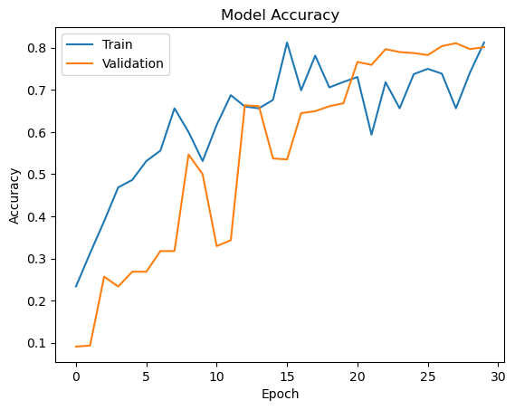

```python
plt.plot(history2.history['accuracy'])
plt.plot(history2.history['val_accuracy'])
plt.title('Model Accuracy')
plt.ylabel('Accuracy')
plt.xlabel('Epoch')
plt.legend(['Train', 'Validation'], loc='upper left')
plt.show()
```

#### Evaluating the Model Performance on Test data

```python
accuracy = model2.evaluate(X_test_normalized, y_test_encoded, verbose=2)
```

```
15/15 - 0s - 19ms/step - accuracy: 0.7853 - loss: 0.6481
```

#### Observations

- After making the changes, our model **accuracy** jumped **from 67.37% to 78.53%**.

#### Plotting the Confusion Matrix

```python
# Here we would get the output as probablities for each category
y_pred=model2.predict(X_test_normalized)
```

```
15/15 ━━━━━━━━━━━━━━━━━━━━ 1s 31ms/step
```

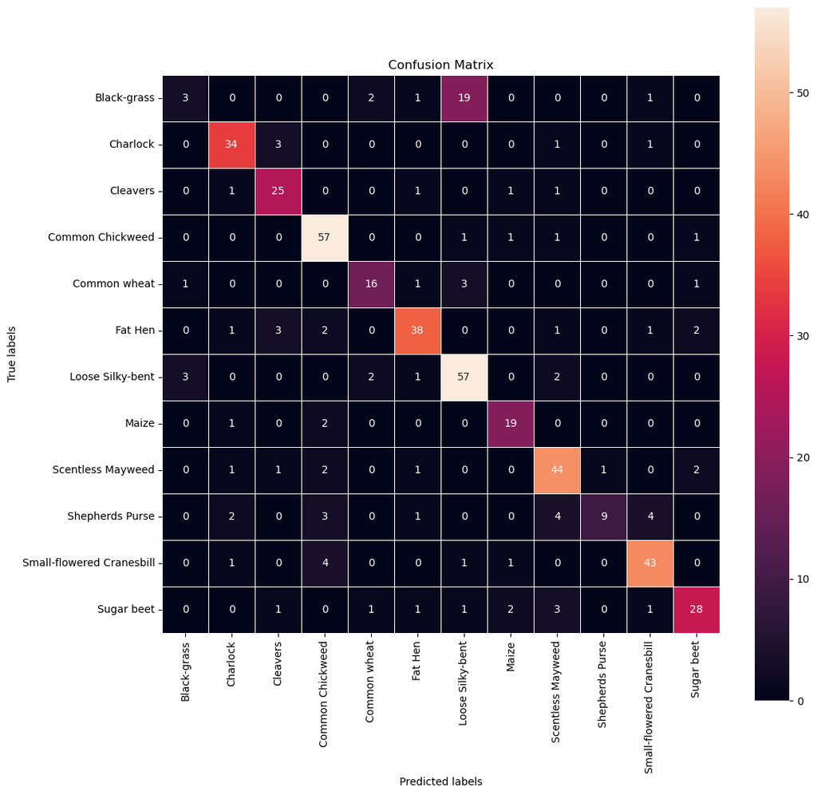

```python
# Obtaining the categorical values from y_test_encoded and y_pred
y_pred_arg=np.argmax(y_pred,axis=1)
y_test_arg=np.argmax(y_test_encoded,axis=1)

# Plotting the Confusion Matrix using confusion matrix() function which is also predefined tensorflow module
confusion_matrix = tf.math.confusion_matrix(y_test_arg,y_pred_arg)
f, ax = plt.subplots(figsize=(12, 12))
sns.heatmap(
    confusion_matrix,
    annot=True,
    linewidths=.4,
    fmt="d",
    square=True,
    ax=ax
)
# Setting the labels to both the axes
ax.set_xlabel('Predicted labels');ax.set_ylabel('True labels');
ax.set_title('Confusion Matrix');
ax.xaxis.set_ticklabels(list(enc.classes_),rotation=90)
ax.yaxis.set_ticklabels(list(enc.classes_),rotation=0)
plt.show()
```

#### Observations

- When compared with the **Confusion Matrix** for the previous model, we can see that the number of **incorrect predictions have reduced** (non-zero numbers off the diagonal).
- We can notice that due to really high similarity, ***Black-grass*** almost always gets predicted as ***Loose Silky-bent***.
- But, otherwise most of the other species of plants are mostly predicted correctly by the udpated model.

#### Plotting Classification Report

```python
# Plotting the classification report
cr=metrics.classification_report(y_test_arg,y_pred_arg)
print(cr)
```

```
              precision    recall  f1-score   support

           0       0.43      0.12      0.18        26
           1       0.83      0.87      0.85        39
           2       0.76      0.86      0.81        29
           3       0.81      0.93      0.87        61
           4       0.76      0.73      0.74        22
           5       0.84      0.79      0.82        48
           6       0.70      0.88      0.78        65
           7       0.79      0.86      0.83        22
           8       0.77      0.85      0.81        52
           9       0.90      0.39      0.55        23
          10       0.84      0.86      0.85        50
          11       0.82      0.74      0.78        38

    accuracy                           0.79       475
   macro avg       0.77      0.74      0.74       475
weighted avg       0.78      0.79      0.77       475
```

## Final Model

Comment on the final model you have selected and use the same in the below code to visualize the image.

#### Final Model Selection Criteria

- As obvious, **model2** built using augmented data and configured to lower the learning rate as needed, performed much better than our original model.
  - Hence, our **final model** will be **model2**.

### Visualizing the prediction

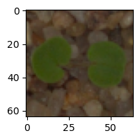

```
1/1 ━━━━━━━━━━━━━━━━━━━━ 0s 17ms/step
Predicted Label ['Common Chickweed']
True Label Common Chickweed
```

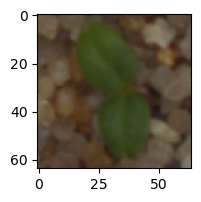

```
1/1 ━━━━━━━━━━━━━━━━━━━━ 0s 17ms/step
Predicted Label ['Small-flowered Cranesbill']
True Label Small-flowered Cranesbill
```

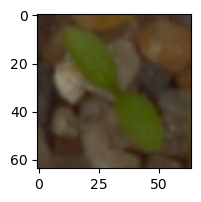

```
1/1 ━━━━━━━━━━━━━━━━━━━━ 0s 16ms/step
Predicted Label ['Loose Silky-bent']
True Label Loose Silky-bent
```

[figure not shown]

```
1/1 ━━━━━━━━━━━━━━━━━━━━ 0s 15ms/step
Predicted Label ['Loose Silky-bent']
True Label Loose Silky-bent
```

```python
# Visualizing the predicted and correct label of some sample images from test data
plt.figure(figsize=(2,2))
plt.imshow(X_test[2])
plt.show()
print('Predicted Label', enc.inverse_transform(model2.predict((X_test_normalized[45].reshape(1,64,64,3)))))
print('True Label', enc.inverse_transform(y_test_encoded)[45])

plt.figure(figsize=(2,2))
plt.imshow(X_test[33])
plt.show()
print('Predicted Label', enc.inverse_transform(model2.predict((X_test_normalized[69].reshape(1,64,64,3)))))
print('True Label', enc.inverse_transform(y_test_encoded)[69])

plt.figure(figsize=(2,2))
plt.imshow(X_test[59],)
plt.show()
print('Predicted Label', enc.inverse_transform(model2.predict((X_test_normalized[27].reshape(1,64,64,3)))))
print('True Label', enc.inverse_transform(y_test_encoded)[27])

plt.figure(figsize=(2,2))
plt.imshow(X_test[36])
plt.show()
print('Predicted Label', enc.inverse_transform(model2.predict((X_test_normalized[73].reshape(1,64,64,3)))))
print('True Label', enc.inverse_transform(y_test_encoded)[73])
```